# Assignment for Reproducible Research Coursera Course

## Downloading and Organizing the Data

load libraries

```r
library(knitr)
library(plyr)
library(dplyr)
```

set global options for R markdown:

```r
opts_chunk$set(echo = TRUE)
```

download and load the data:

```r
tmpdir = tempdir()
url = 'https://d396qusza40orc.cloudfront.net/repdata%2Fdata%2Factivity.zip'
file = basename(url)
download.file(url, file)
unzip(file, exdir = tmpdir)
file = list.files(tempdir(), pattern = "*.csv", full.names = T)
data = read.csv(file)
unlink(tmpdir)
```

process the data: mutate date to date form

```r
data = mutate(data, date = as.Date(date, "%Y-%m-%d"))
```

## Summary Statistics and Exploratory Plots

calculate the total number of steps taken per day

```r
sumStepsByDate = ddply(data, .(date), summarise, sum=sum(steps, na.rm = TRUE))
```

**histogram** of the total number of steps taken each day including the mean and median of the total number of steps taken per day:

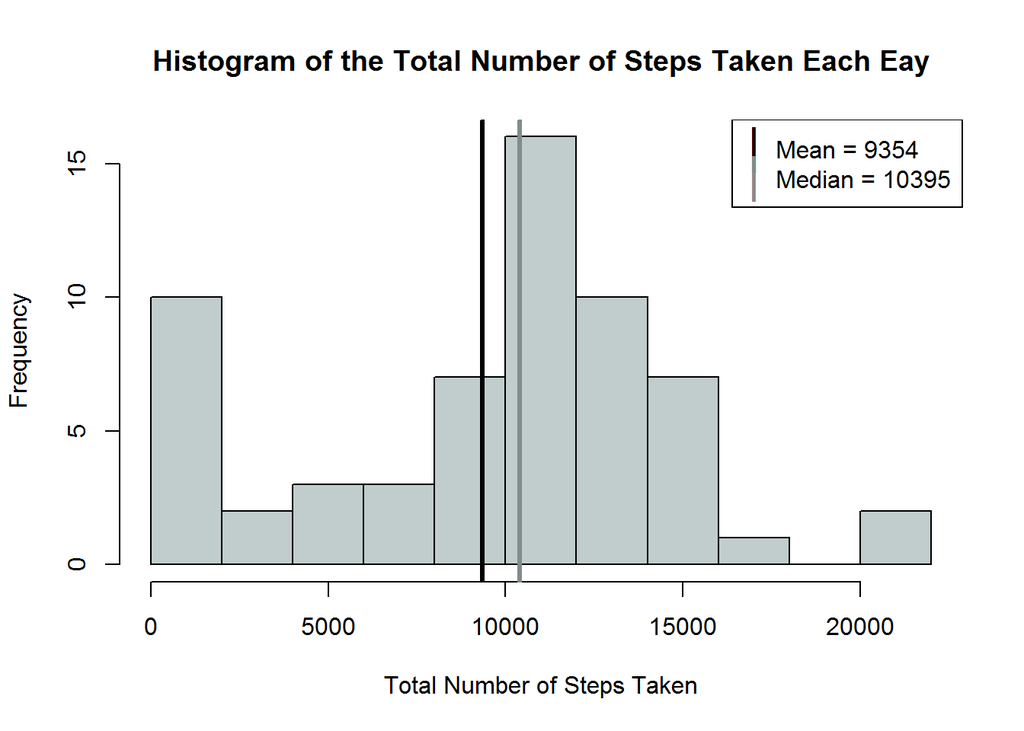

```r
hist(sumStepsByDate$sum, col = "azure3", breaks = 10, main = "Histogram of the Total Number of Steps Taken Each Eay", xlab = "Total Number of Steps Taken")
meanS = round(mean(sumStepsByDate$sum))
medianS = round(median(sumStepsByDate$sum))
abline(v=meanS, col = "black", lwd = 3)
abline(v=medianS, col = "azure4", lwd = 3)
legend("topright", pch = "|", col = c("black", "azure4"), legend = c(paste0("Mean = ",meanS), paste0("Median = ",medianS)), pt.cex = 2)
```

a time series plot (i.e. type = “l”) of the 5-minute interval (x-axis) and the average number of steps taken, averaged across all days (y-axis)

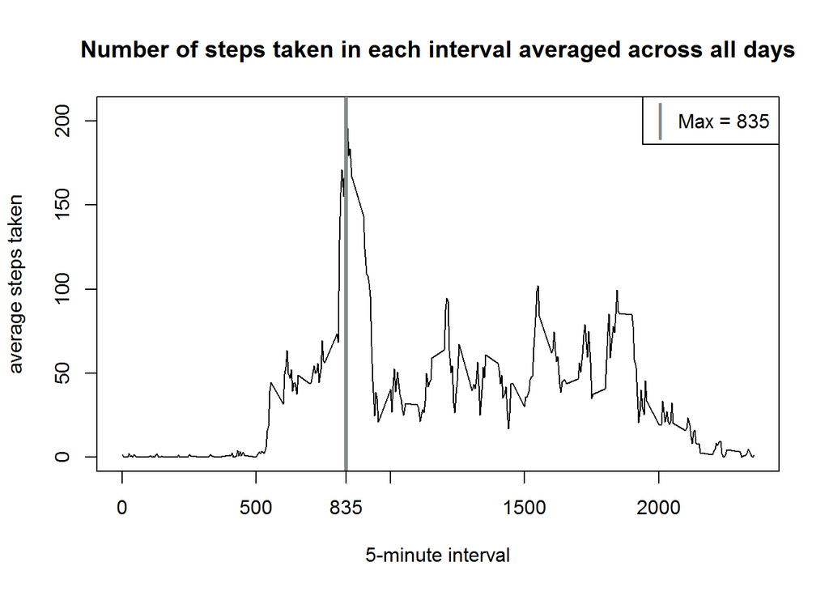

```r
meanStepsByInterval = ddply(data, .(interval), summarise, average = mean(steps, na.rm = TRUE))
plot(meanStepsByInterval, type = "l", xlab = "5-minute interval", ylab = "average steps taken", main = "Number of steps taken in each interval averaged across all days", xaxt = "n")
maxInterval = data$interval[which.max(meanStepsByInterval$average)]
abline(v=maxInterval, col = "azure4", lwd = 3)
legend("topright", pch = "|", col = c("azure4"), legend = paste0("Max = ",maxInterval), pt.cex = 2)
xTicks = seq(0, data$interval[length(data$interval)]+5, 500)
newXTicks = c(xTicks,maxInterval)
newXTicks = newXTicks[order(newXTicks)]
axis(1, round(newXTicks))
```

## Missing values

```r
sumNA = sum(!complete.cases(data))
percentNA = round(sumNA/dim(data)[1],2)*100
```

There are 2304 rows with missing values which is 13% of the rows.

Fill missing values by 5-minute interval average

```r
repData = rep(meanStepsByInterval$average,length(unique(data$date)))
dataFilledNA = data
dataFilledNA$steps[is.na(data$steps)] = repData[is.na(data$steps)]
```

histogram of the total number of steps taken each day with filled missing values

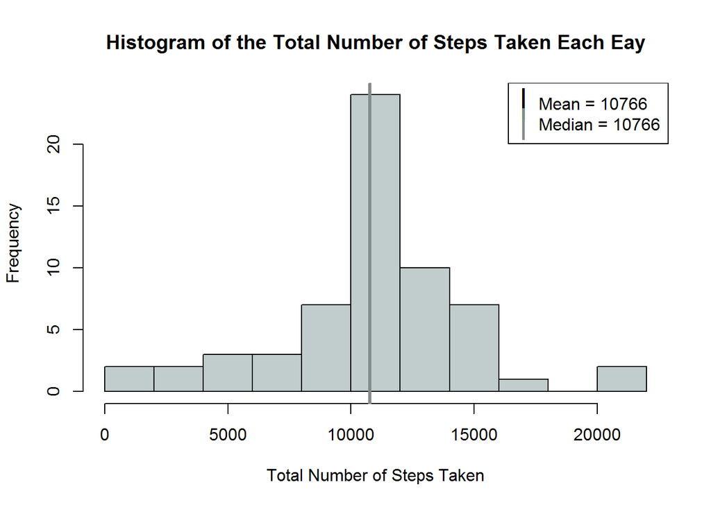

```r
sumStepsByDate = ddply(dataFilledNA, .(date), summarise, sum=sum(steps, na.rm = TRUE))
hist(sumStepsByDate$sum, col = "azure3", breaks = 10, main = "Histogram of the Total Number of Steps Taken Each Eay", xlab = "Total Number of Steps Taken")
meanS = round(mean(sumStepsByDate$sum))
medianS = round(median(sumStepsByDate$sum))
abline(v=meanS, col = "black", lwd = 3)
abline(v=medianS, col = "azure4", lwd = 3)
legend("topright", pch = "|", col = c("black", "azure4"), legend = c(paste0("Mean = ",meanS), paste0("Median = ",medianS)), pt.cex = 2)
```

Do these values differ from the estimates from the first part of the assignment? Yes. They are higher.

What is the impact of imputing missing data on the estimates of the total daily number of steps?.

```
Missing data contributed 0 to the sum thus imputing missing data by any (positive) value, increases the sum of the total daily number of steps.
```

## Differences in Activity Patterns between Weekdays and Weekends?

create a factor variable in the data with two levels indicating whether a date is a weekday or weekend

```r
dataFilledNA$dateType = weekdays(dataFilledNA$date) %in% c("Saturday","Sunday")
dataFilledNA$dateType = factor(dataFilledNA$dateType, labels = c("weekday", "weekend"))
```

[output not shown]

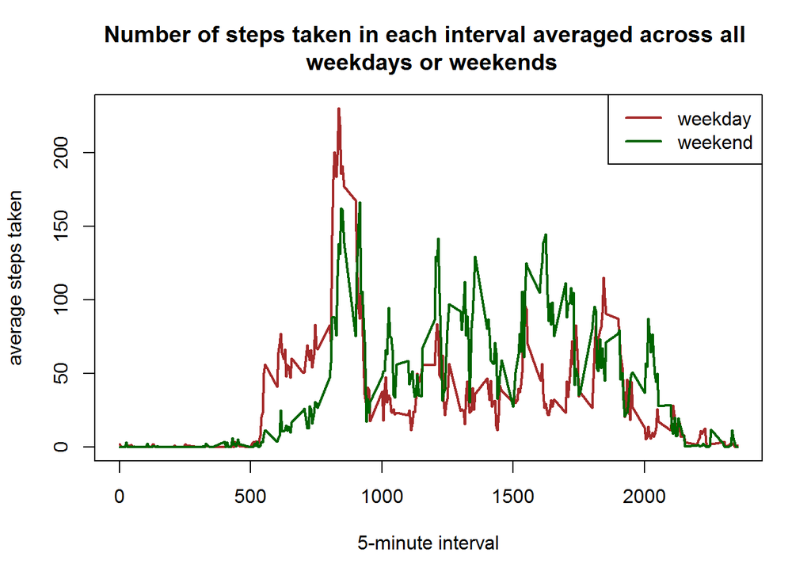

```r
meanStepsByIntervalWeekday = ddply(dataFilledNA[dataFilledNA$dateType == "weekday",], .(interval), summarise, average = mean(steps, na.rm = TRUE))
meanStepsByIntervalWeekend = ddply(dataFilledNA[dataFilledNA$dateType == "weekend",], .(interval), summarise, average = mean(steps, na.rm = TRUE))

plot(meanStepsByIntervalWeekday, type = "l", lwd = 2, xlab = "5-minute interval", ylab = "average steps taken", col = "brown", main = "Number of steps taken in each interval averaged across all \n weekdays or weekends")
lines(meanStepsByIntervalWeekend, col = "darkgreen", lwd = 2)
legend("topright", lty = 1, col = c("brown", "darkgreen"), legend = levels(dataFilledNA$dateType), lwd = 2)
```